# Análise de Visualização - Spotify 2023

Nicolas Pereira de Mello Andrade

Bibliotecas utilizadas e carregamento do dataset:

```r
library(tidyverse)
library(janitor)
library(summarytools)
library(stringr)

spotify <- read_csv("spotify-2023.csv", locale = locale(encoding = "UTF-8"))
spotify$streams <- as.numeric(str_replace_all(spotify$streams, ",", ""))
```

## Estrutura Inicial do Dataset

Visualização da estrutura geral do dataset:

```r
glimpse(spotify)
```

```
## Rows: 953
## Columns: 24
## $ track_name           <chr> "Seven (feat. Latto) (Explicit Ver.)", "LALA", "v…
## $ `artist(s)_name`     <chr> "Latto, Jung Kook", "Myke Towers", "Olivia Rodrig…
## $ artist_count         <dbl> 2, 1, 1, 1, 1, 2, 2, 1, 1, 2, 2, 1, 1, 1, 1, 1, 1…
## $ released_year        <dbl> 2023, 2023, 2023, 2019, 2023, 2023, 2023, 2023, 2…
## $ released_month       <dbl> 7, 3, 6, 8, 5, 6, 3, 7, 5, 3, 4, 7, 1, 4, 3, 12, …
## $ released_day         <dbl> 14, 23, 30, 23, 18, 1, 16, 7, 15, 17, 17, 7, 12, …
## $ in_spotify_playlists <dbl> 553, 1474, 1397, 7858, 3133, 2186, 3090, 714, 109…
## $ in_spotify_charts    <dbl> 147, 48, 113, 100, 50, 91, 50, 43, 83, 44, 40, 55…
## $ streams              <dbl> 141381703, 133716286, 140003974, 800840817, 30323…
## $ in_apple_playlists   <dbl> 43, 48, 94, 116, 84, 67, 34, 25, 60, 49, 41, 37, …
## $ in_apple_charts      <dbl> 263, 126, 207, 207, 133, 213, 222, 89, 210, 110, …
## $ in_deezer_playlists  <dbl> 45, 58, 91, 125, 87, 88, 43, 30, 48, 66, 54, 21, …
## $ in_deezer_charts     <dbl> 10, 14, 14, 12, 15, 17, 13, 13, 11, 13, 12, 5, 58…
## $ in_shazam_charts     <dbl> 826, 382, 949, 548, 425, 946, 418, 194, 953, 339,…
## $ bpm                  <dbl> 125, 92, 138, 170, 144, 141, 148, 100, 130, 170, …
## $ key                  <chr> "B", "C#", "F", "A", "A", "C#", "F", "F", "C#", "…
## $ mode                 <chr> "Major", "Major", "Major", "Major", "Minor", "Maj…
## $ `danceability_%`     <dbl> 80, 71, 51, 55, 65, 92, 67, 67, 85, 81, 57, 78, 7…
## $ `valence_%`          <dbl> 89, 61, 32, 58, 23, 66, 83, 26, 22, 56, 56, 52, 6…
## $ `energy_%`           <dbl> 83, 74, 53, 72, 80, 58, 76, 71, 62, 48, 72, 82, 6…
## $ `acousticness_%`     <dbl> 31, 7, 17, 11, 14, 19, 48, 37, 12, 21, 23, 18, 6,…
## $ `instrumentalness_%` <dbl> 0, 0, 0, 0, 63, 0, 0, 0, 0, 0, 0, 0, 0, 0, 0, 17,…
## $ `liveness_%`         <dbl> 8, 10, 31, 11, 11, 8, 8, 11, 28, 8, 27, 15, 3, 9,…
## $ `speechiness_%`      <dbl> 4, 4, 6, 15, 6, 24, 3, 4, 9, 33, 5, 7, 7, 3, 6, 4…
```

Padronização dos nomes das colunas:

```r
spotify <- clean_names(spotify)
```

Remoção de caracteres especiais das colunas textuais:

```r
colunas_texto <- sapply(spotify, is.character)
spotify[colunas_texto] <- lapply(spotify[colunas_texto], function(coluna) {
  str_replace_all(coluna, "[^\\x00-\\x7F]", "")
})
```

Resumo estatístico visual completo:

```r
dfSummary(spotify)
```

```
## Data Frame Summary
## spotify
## Dimensions: 953 x 24
## Duplicates: 0
##
## ------------------------------------------------------------------------------------------------------------------------------------
## No   Variable                   Stats / Values                      Freqs (% of Valid)    Graph                 Valid      Missing
## ---- -------------------------- ----------------------------------- --------------------- --------------------- ---------- ---------
## 1    track_name                 1. (Empty string)                     2 ( 0.2%)                                 953        0
##      [character]                2. About Damn Time                    2 ( 0.2%)                                 (100.0%)   (0.0%)
##                                 3. Daylight                           2 ( 0.2%)
##                                 4. Die For You                        2 ( 0.2%)
##                                 5. Flowers                            2 ( 0.2%)
##                                 6. Let It Snow! Let It Snow!          2 ( 0.2%)
##                                 7. Miss You                           2 ( 0.2%)
##                                 8. Numb                               2 ( 0.2%)
##                                 9. SNAP                               2 ( 0.2%)
##                                 10. SPIT IN MY FACE!                  2 ( 0.2%)
##                                 [ 932 others ]                      933 (97.9%)           IIIIIIIIIIIIIIIIIII
##
## 2    artist_s_name              1. Taylor Swift                      34 ( 3.6%)                                 953        0
##      [character]                2. The Weeknd                        22 ( 2.3%)                                 (100.0%)   (0.0%)
##                                 3. Bad Bunny                         19 ( 2.0%)
##                                 4. SZA                               19 ( 2.0%)
##                                 5. Harry Styles                      17 ( 1.8%)
##                                 6. Kendrick Lamar                    12 ( 1.3%)
##                                 7. Morgan Wallen                     11 ( 1.2%)
##                                 8. Ed Sheeran                         9 ( 0.9%)
##                                 9. BTS                                8 ( 0.8%)
##                                 10. Drake, 21 Savage                  8 ( 0.8%)
##                                 [ 635 others ]                      794 (83.3%)           IIIIIIIIIIIIIIII
##
## 3    artist_count               Mean (sd) : 1.6 (0.9)               1 : 587 (61.6%)       IIIIIIIIIIII          953        0
##      [numeric]                  min < med < max:                    2 : 254 (26.7%)       IIIII                 (100.0%)   (0.0%)
##                                 1 < 1 < 8                           3 :  85 ( 8.9%)       I
##                                 IQR (CV) : 1 (0.6)                  4 :  15 ( 1.6%)
##                                                                     5 :   5 ( 0.5%)
##                                                                     6 :   3 ( 0.3%)
##                                                                     7 :   2 ( 0.2%)
##                                                                     8 :   2 ( 0.2%)
```

[output cut: 115 more lines]

```
##                                 IQR (CV) : 0 (5.3)                                        :
##                                                                                           :
##
## 23   liveness_percent           Mean (sd) : 18.2 (13.7)             68 distinct values    :                     953        0
##      [numeric]                  min < med < max:                                          :                     (100.0%)   (0.0%)
##                                 3 < 12 < 97                                               :
##                                 IQR (CV) : 14 (0.8)                                       : :
##                                                                                           : : : : .
##
## 24   speechiness_percent        Mean (sd) : 10.1 (9.9)              48 distinct values    :                     953        0
##      [numeric]                  min < med < max:                                          :                     (100.0%)   (0.0%)
##                                 2 < 6 < 64                                                :
##                                 IQR (CV) : 7 (1)                                          :
##                                                                                           : : . . .
## ------------------------------------------------------------------------------------------------------------------------------------
```

## Contagens e Verificação de Dados

Contagem dos valores distintos em variáveis-chave:

```r
# Identifica o número de músicas únicas
n_distinct(spotify$track_name)
```

```
## [1] 942
```

```r
# Mostra quantos artistas diferentes estão presentes
n_distinct(spotify$artist_s_name)
```

```
## [1] 645
```

```r
# Revela quantos anos distintos de lançamento existem no dataset
n_distinct(spotify$released_year)
```

```
## [1] 50
```

```r
# Informa a quantidade de modos musicais distintos (geralmente dois: maior e menor)
n_distinct(spotify$mode)
```

```
## [1] 2
```

Verificação da quantidade de valores ausentes por coluna:

```r
spotify %>%
  summarise(across(everything(), ~ sum(is.na(.)))) %>%
  t()
```

```
##                          [,1]
## track_name                  0
## artist_s_name               0
## artist_count                0
## released_year               0
## released_month              0
## released_day                0
## in_spotify_playlists        0
## in_spotify_charts           0
## streams                     1
## in_apple_playlists          0
## in_apple_charts             0
## in_deezer_playlists         0
## in_deezer_charts            0
## in_shazam_charts           50
## bpm                         0
## key                        95
## mode                        0
## danceability_percent        0
## valence_percent             0
## energy_percent              0
## acousticness_percent        0
## instrumentalness_percent    0
## liveness_percent            0
## speechiness_percent         0
```

## Média de Streams por Ano

Agrupamento por ano e cálculo da média de streams:

```r
spotify %>%
  group_by(released_year) %>%
  summarise(media_streams = mean(streams, na.rm = TRUE)) %>%
  arrange(desc(media_streams))
```

```
## # A tibble: 50 × 2
##    released_year media_streams
##            <dbl>         <dbl>
##  1          1975   2103052676
##  2          1983   1593270737
##  3          2003   1584021370.
##  4          1987   1553497987
##  5          2018   1503052239
##  6          1994   1449779435
##  7          2002   1446620470.
##  8          2017   1367723437.
##  9          2012   1341534279.
## 10          1998   1284942608
## # ℹ 40 more rows
```

## Filtragem de Anos com Muitas Músicas

Remoção dos anos com menos de 10 músicas:

```r
spotify_filtrado <- spotify %>%
  group_by(released_year) %>%
  filter(n() > 10) %>%
  ungroup()
```

## Gráfico de Dispersão

**Pergunta:** Existe uma relação entre a danceabilidade da música e seu número de streams?

**Explicação:** Cria gráfico de dispersão com linha de tendência (regressão linear):

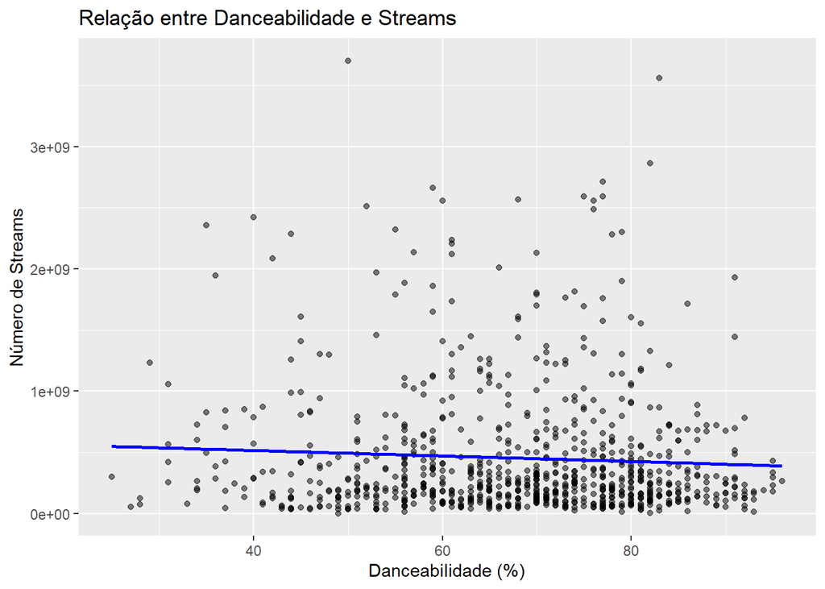

```r
ggplot(spotify_filtrado, aes(x = danceability_percent, y = streams)) +
  geom_point(alpha = 0.5) +
  geom_smooth(method = "lm", se = FALSE, color = "blue") +
  labs(
    title = "Relação entre Danceabilidade e Streams",
    x = "Danceabilidade (%)",
    y = "Número de Streams"
  )
```

**Interpretação:**  
O gráfico mostra uma fraca tendência negativa: músicas mais dançantes não têm necessariamente mais streams. A linha azul representa a regressão linear ajustada.

**Pergunta:** Existe relação entre a energia da música e a sua popularidade (streams)?

**Explicação:** Gera gráfico de dispersão para examinar a relação entre energia e número de streams:

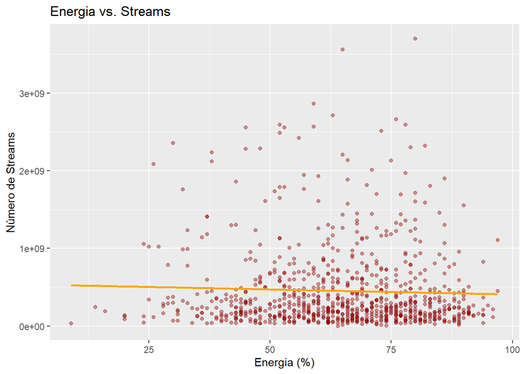

```r
ggplot(spotify_filtrado, aes(x = energy_percent, y = streams)) +
  geom_point(alpha = 0.4, color = "darkred") +
  geom_smooth(method = "lm", se = FALSE, color = "orange") +
  labs(
    title = "Energia vs. Streams",
    x = "Energia (%)",
    y = "Número de Streams"
  )
```

## Histograma

**Pergunta:** Qual é a distribuição de BPM das músicas mais populares?

**Explicação:** Gera histograma com 30 faixas (bins) para BPM:

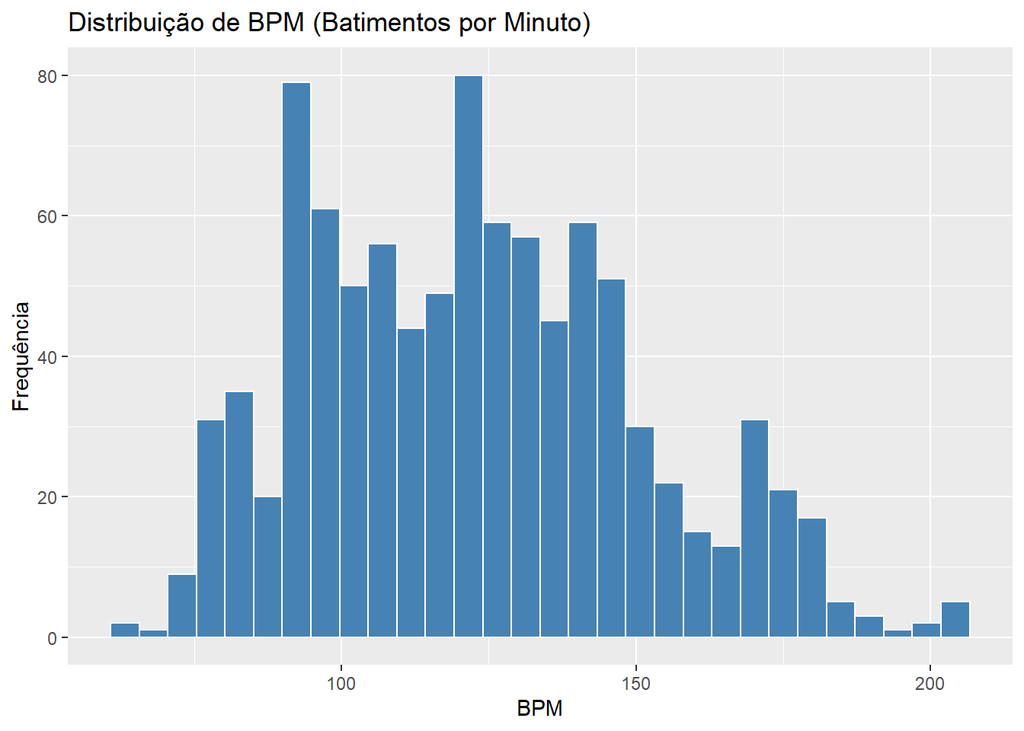

```r
ggplot(spotify, aes(x = bpm)) +
  geom_histogram(fill = "steelblue", bins = 30, color = "white") +
  labs(
    title = "Distribuição de BPM (Batimentos por Minuto)",
    x = "BPM",
    y = "Frequência"
  )
```

**Interpretação:**  
O histograma mostra que a maioria das músicas está entre **90 e 130 BPM**, ritmo comum em gêneros pop e eletrônicos. Há poucas músicas com BPM muito altos ou baixos.

**Pergunta:** Como é distribuído o número de streams (com escala log)?

**Explicação:** Cria histograma da variável `streams`, aplicando transformação logarítmica:

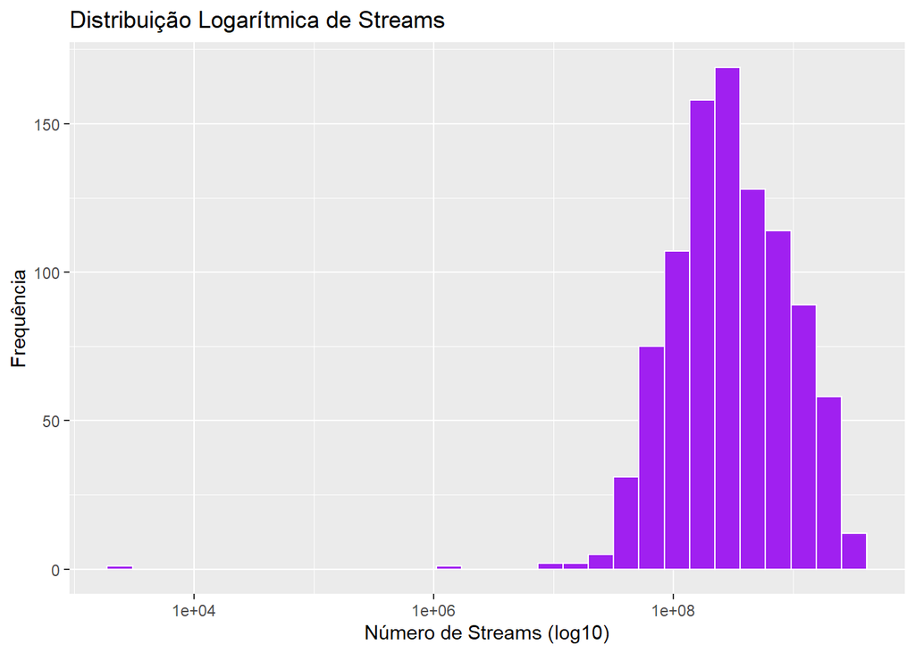

```r
ggplot(spotify, aes(x = streams)) +
  geom_histogram(fill = "purple", bins = 30, color = "white") +
  scale_x_log10() +
  labs(
    title = "Distribuição Logarítmica de Streams",
    x = "Número de Streams (log10)",
    y = "Frequência"
  )
```

## Boxplot

**Pergunta:** O modo musical (maior ou menor) influencia no número de streams?

**Explicação:** Cria boxplot comparando streams entre músicas em modo maior e menor:

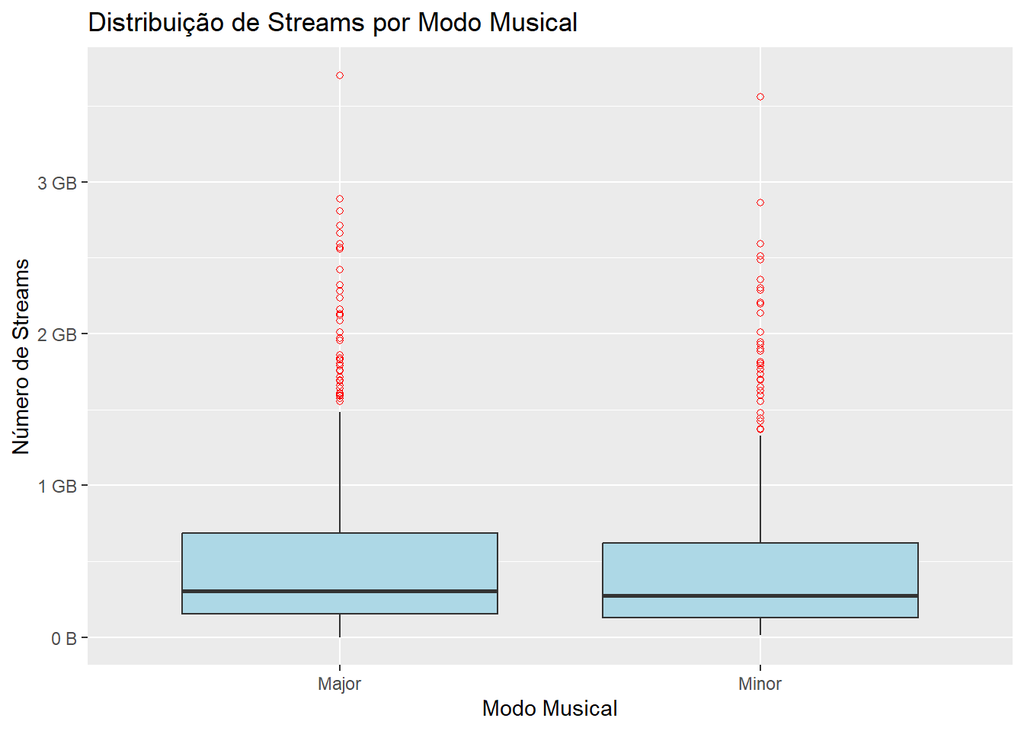

```r
ggplot(spotify, aes(x = mode, y = streams)) +
  geom_boxplot(fill = "lightblue", outlier.color = "red", outlier.shape = 1, na.rm = TRUE) +
  scale_y_continuous(labels = scales::label_number(scale_cut = scales::cut_si("B"))) +
  labs(
    title = "Distribuição de Streams por Modo Musical",
    x = "Modo Musical",
    y = "Número de Streams"
  )
```

**Pergunta:** Há variação na distribuição de streams ao longo dos meses?

**Explicação:** Cria boxplots lado a lado por mês de lançamento:

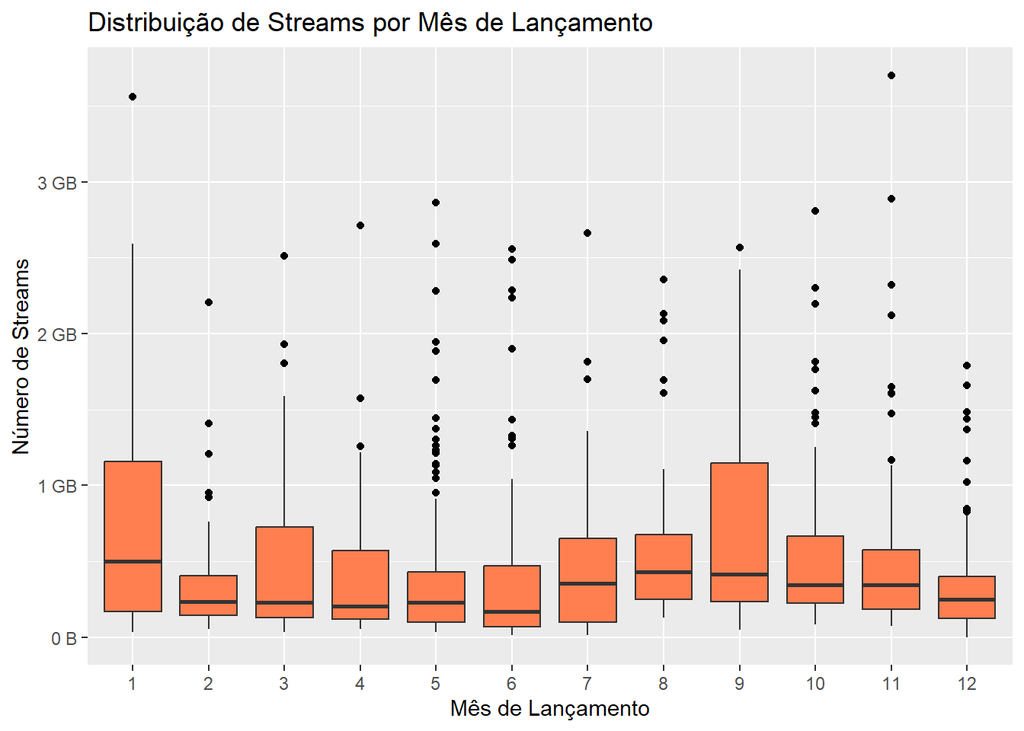

```r
ggplot(spotify, aes(x = factor(released_month), y = streams)) +
  geom_boxplot(fill = "coral", outlier.color = "black", outlier.shape = 16, na.rm = TRUE) +
  scale_y_continuous(labels = scales::label_number(scale_cut = scales::cut_si("B"))) +
  labs(
    title = "Distribuição de Streams por Mês de Lançamento",
    x = "Mês de Lançamento",
    y = "Número de Streams"
  )
```

## Gráfico de Barras

**Pergunta:** Quais são os tons musicais (keys) mais comuns nas músicas mais populares?

**Explicação:** Agrupa por tom (`key`) e ordena pela contagem decrescente:

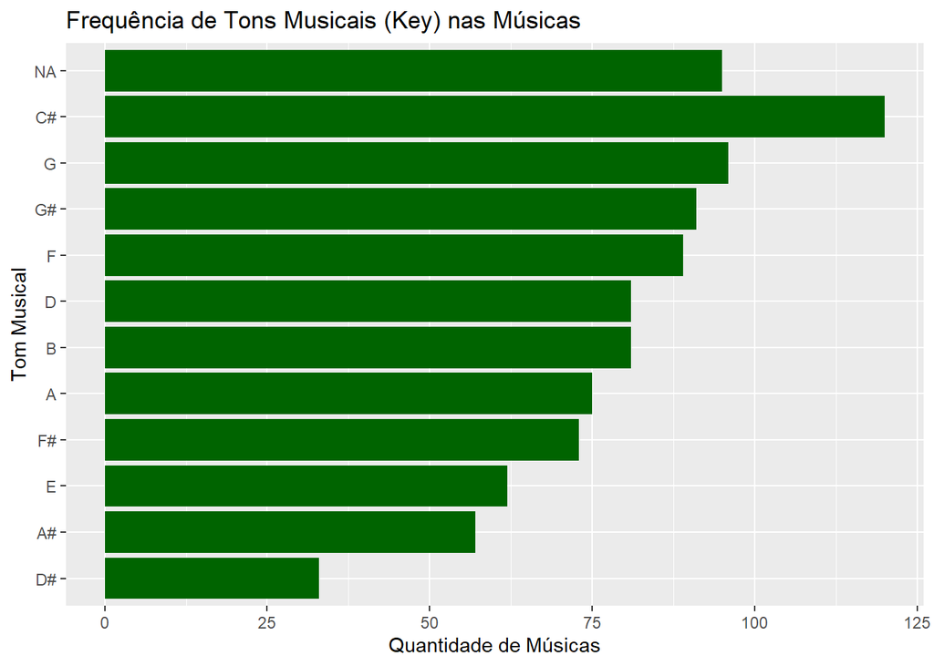

```r
ggplot(spotify %>% count(key, sort = TRUE), aes(x = reorder(key, n), y = n)) +
  geom_bar(stat = "identity", fill = "darkgreen") +
  coord_flip() +
  labs(
    title = "Frequência de Tons Musicais (Key) nas Músicas",
    x = "Tom Musical",
    y = "Quantidade de Músicas"
  )
```

**Interpretação:**  
O gráfico mostra os tons musicais mais frequentes entre as músicas do dataset. Os tons mais utilizados podem indicar preferências harmônicas comuns em músicas populares.

**Pergunta:** Como está distribuída a quantidade de músicas lançadas por ano?

**Explicação:** Gera gráfico de colunas com ordenação e destaque para o tempo:

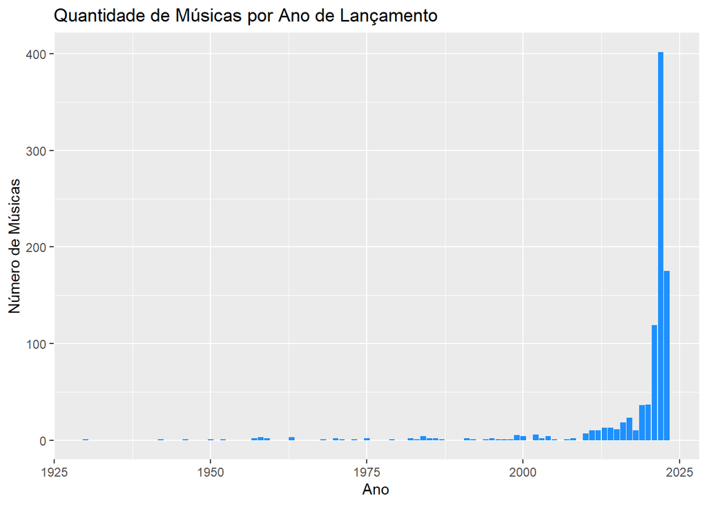

```r
ggplot(spotify %>% count(released_year), aes(x = released_year, y = n)) +
  geom_col(fill = "dodgerblue") +
  labs(
    title = "Quantidade de Músicas por Ano de Lançamento",
    x = "Ano",
    y = "Número de Músicas"
  )
```

**Interpretação:**  
A maior concentração está nos anos mais recentes, refletindo a modernidade do dataset ou uma tendência de crescimento na produção musical recente.

## Gráfico de Linha

**Pergunta:** A média de streams por ano tem aumentado ou diminuído ao longo do tempo?

**Explicação:** Cria gráfico de linha com a média de streams por ano de lançamento:

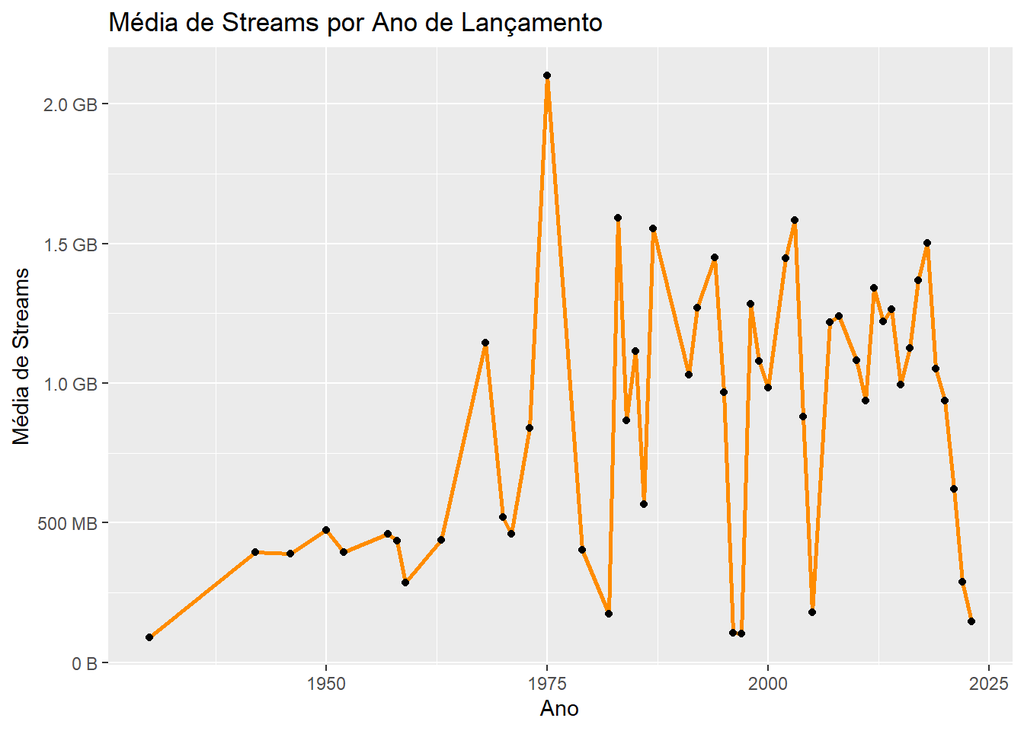

```r
spotify %>%
  group_by(released_year) %>%
  summarise(media_streams = mean(streams, na.rm = TRUE)) %>%
  ggplot(aes(x = released_year, y = media_streams)) +
  geom_line(color = "darkorange", size = 1) +
  geom_point(color = "black") +
  scale_y_continuous(labels = scales::label_number(scale_cut = scales::cut_si("B"))) +
  labs(
    title = "Média de Streams por Ano de Lançamento",
    x = "Ano",
    y = "Média de Streams"
  )
```

**Interpretação:**  
Há variação considerável ao longo das décadas, com picos em anos específicos. Isso pode refletir tanto fenômenos culturais quanto mudanças nas plataformas de streaming.